# R 고급 통계분석 3일차 (4)

Sanghoo Yoon

## 1. 신경망, 딥러닝 팩키지

R에서 신경망, 딥러닝을 돌릴 수 있는 팩키지가 다수 존재한다.

단순한 전방 전달 신경망부터 텐서플로우, MXNet을 활용할 수 있게 하는 팩키지까지 다양하다.

| R 팩키지 | 팩키지 설명 |
| --- | --- |
| nnet | 전방 전달 신경망(feed-forward neural networks) + 다항 로그선형모형(multinomial log-linear models) |
| neuralnet | 역전파 신경망 |
| h2o | H2O지원 |
| RSNNS | Stuttgart Neural Network Simulator (SNNS) 지원 |
| tensorflow | 구글 텐서플로우 |
| deepnet | 딥러닝 툴킷 |
| darch | 볼츠만 기계(Deep Architectures and Restricted Boltzmann Machines) |
| rnn | 순환신경망(Recurrent Neural Networks) |
| FCNN4R | FCNN 라이브러리 |
| rcppDL | 다양한 딥러닝 구현 라이브러리 |
| deepr | darch, deepnet 을 사용하기 쉽게 함 |
| MXNetR | MXNet 라이브러리 |

딥러닝에 활용되는 방법론을 중심으로 살펴보면 다음과 같다. 다만 최신 텐서플로우는 포함되어 있지 않다.

[output not shown]

### 1.1. 케라스(Keras)

텐서플로우(tensorflow), 티아오(theano), 마이크로소프트 CNTK 등 딥러닝 라이브러리가 너무 많아 어떤 팩키지를 골라야 하나 고민이 많다. R을 통해 모형을 개발하고 데이터를 분석하는 입장에서는 부족한 시간에 참 고민이 되는 지점이다. 케라스가 다음 4가지 품질속성을 중심으로 딥러닝 모형 개발에 출사표를 던졌다.

```
모듈화 (Modularity)
최소주의 (Minimalism)
쉬운 확장성
파이썬 기반
```

그런데, 케라스를 R에서 사용할 수 있도록 개발된 팩키지가 Taylor Arnold가 주축이 된 kerasR, RStudio에서 개발한 keras 두가지 버젼이 존재한다. 만약 RStudio 개발 생태계에 익숙하다면 `keras` 팩키지가 시작하기 딱 좋을 수 있다.

### 1.2. 케라스 설치

`kerasR` 보다 `keras` 설치가 단순하다. `keras`를 설치하고 나서, `install_tensorflow()`를 실행하면 된다.

다만, 윈도우 사용자의 경우 아나콘다를 먼저 설치하고 나서 install_tensorflow() 명령어 실행을 추천한다.

```r
 library(keras)
# install_tensorflow()
 library(tidyverse)
```

### 1.3 iris 데이터 딥러닝 시작하기 전 데이터 전처리

데이터 전처리는 크게 관측점 데이터, 즉 행렬로 봤을 때 2/3 행을 훈련데이터로 사용하고, 1/3 데이터는 검증 데이터로 활용한다. 즉, 개발된 모형의 참성능은 검증데이터 1/3을 활용하여 모형 성능을 검증한다.

피쳐는 정규화과정을 거쳐야 하는데 keras 내부에 normalize() 함수가 있어 쉽게 정규화할 수 있다. 또한, One-Hot 인코딩기법(통계에서는 가변수, dummy variable)을 통해 범주형 데이터를 0과 1만 갖는 벡터로 변환한다.

```r
library(keras)

# 1. 붓꽃 데이터 -------------------------------------
# 1.1. 붓꽃 데이터 가져오기 --------------------------
iris <- read_csv("http://archive.ics.uci.edu/ml/machine-learning-databases/iris/iris.data", col_names = FALSE)
# 1.2. 데이터프레임을 행렬로 변환 -------------------
iris[,5] <- as.numeric(as.factor(unlist(iris[,5]))) -1
iris <- as.matrix(iris)
dimnames(iris) <- NULL

iris_x <- normalize(iris[,1:4])
iris_mat <- cbind(iris_x, Species=as.numeric(factor(iris[,5]))-1)
names(iris_mat) <- NULL

# 3. 딥러닝 모형 -----------------------------------
## 3.1. 훈련표본과 검증표본 -------------------------
ind <- sample(2, nrow(iris_mat), replace=TRUE, prob=c(0.67, 0.33))

### 모형 설계행렬
iris.training <- iris_mat[ind==1, 1:4]
iris.test <- iris_mat[ind==2, 1:4]

### 모형 예측변수
iris.trainingtarget <- iris_mat[ind==1, 5]
iris.testtarget <- iris_mat[ind==2, 5]

### One-Hot 인코딩: 훈련예측변수
iris.trainLabels <- to_categorical(iris.trainingtarget)

### One-Hot 인코딩: 검증예측변수
iris.testLabels <- to_categorical(iris.testtarget)

## 3.2. 모형 개발 -------------------------
set.seed(777)
### 3.2.1. 모형 초기화
model <- keras_model_sequential()

### 3.2.2. 모형에 계층 추가

# 4 inputs -> [8 hidden nodes] -> 3 outputs
model %>%
  layer_dense(units = 8, activation = 'relu', input_shape = c(4)) %>%
  layer_dropout(rate = 0.5) %>%
  layer_dense(units = 3, activation = 'softmax')

### 3.2.3. 모형 살펴보기
summary(model)
```

```
## Model: "sequential"
## ________________________________________________________________________________
## Layer (type)                        Output Shape                    Param #
## ================================================================================
## dense (Dense)                       (None, 8)                       40
## ________________________________________________________________________________
## dropout (Dropout)                   (None, 8)                       0
## ________________________________________________________________________________
## dense_1 (Dense)                     (None, 3)                       27
## ================================================================================
## Total params: 67
## Trainable params: 67
## Non-trainable params: 0
## ________________________________________________________________________________
```

```r
get_config(model)
```

[output not shown]

```r
get_layer(model, index = 1)
```

```
## <tensorflow.python.keras.layers.core.Dense>
```

```r
model$layers
```

```
## [[1]]
## <tensorflow.python.keras.layers.core.Dense>
##
## [[2]]
## <tensorflow.python.keras.layers.core.Dropout>
##
## [[3]]
## <tensorflow.python.keras.layers.core.Dense>
```

```r
model$inputs
```

```
## [[1]]
## Tensor("dense_input:0", shape=(None, 4), dtype=float32)
```

```r
model$outputs
```

```
## [[1]]
## Tensor("dense_1/Identity:0", shape=(None, 3), dtype=float32)
```

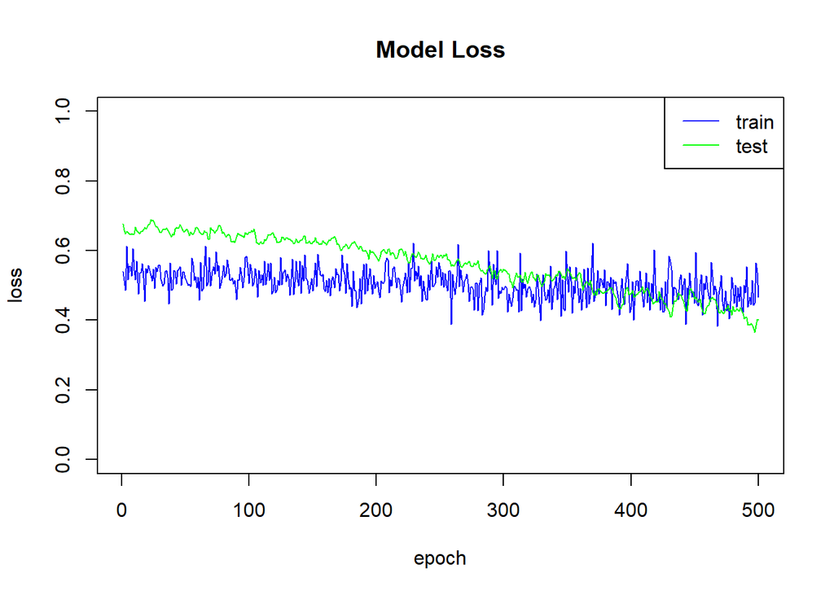

```r
### 3.2.4. 모형 컴파일
model %>% compile(
  loss = 'categorical_crossentropy',
  optimizer = 'adam',
  metrics = 'accuracy'
)

### 3.2.5. 모형 적합
model %>% fit(
  iris.training,
  iris.trainLabels,
  epochs = 500,
  batch_size = 5,
  validation_split = 0.1
)

history <- model %>% fit(
  iris.training,
  iris.trainLabels,
  epochs = 500,
  batch_size = 5,
  validation_split = 0.1
)

### 모형 수렴
plot(history$metrics$loss, main="Model Loss", xlab = "epoch", ylab="loss", col="blue", type="l",
     ylim=c(0,1))
lines(history$metrics$val_loss, col="green")
legend("topright", c("train","test"), col=c("blue", "green"), lty=c(1,1))
```

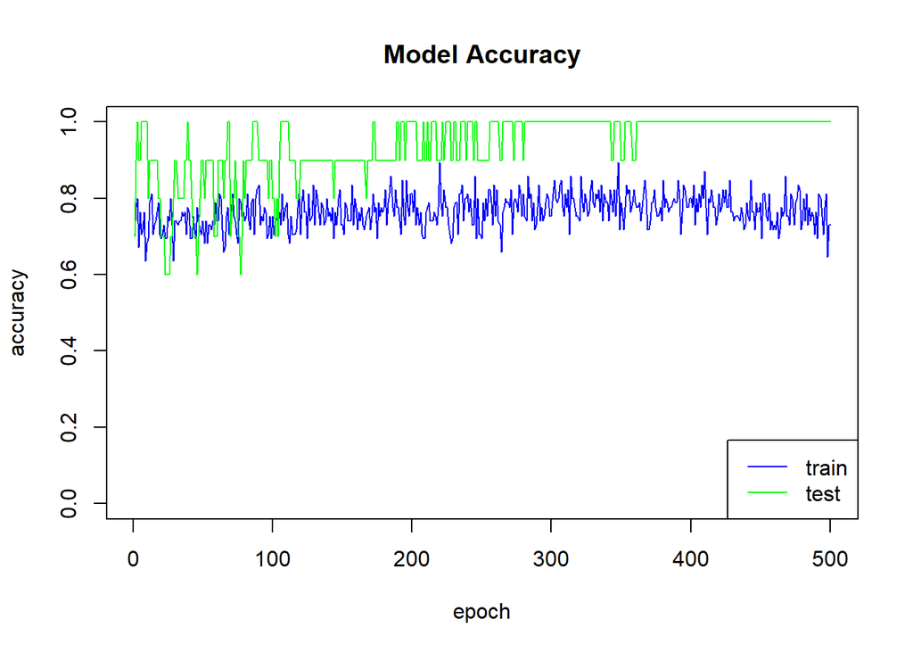

```r
### 모형 정확성
plot(history$metrics$acc, main="Model Accuracy", xlab = "epoch", ylab="accuracy", col="blue", type="l",
     ylim=c(0,1))
lines(history$metrics$val_acc, col="green")
legend("bottomright", c("train","test"), col=c("blue", "green"), lty=c(1,1))
```

```r
## 3.2.7. 검증표본을 통한 평가
pred_mat <- model %>% predict(iris.test, batch_size = 5) %>% data.frame

pred_mat <- pred_mat %>%
  mutate(max_prob = max.col(., ties.method = "last")-1)

### 오차 행렬(Confusion Matrix)
table(iris.testtarget, pred_mat$max_prob)
```

```
##
## iris.testtarget  0  1  2
##               0 19  0  0
##               1  0 20  1
##               2  0  1 14
```

```r
### 모형 정확도 평가
score <- model %>%
  evaluate(iris.test, iris.testLabels, batch_size = 128)

score
```

```
## $loss
## [1] 0.2870477
##
## $accuracy
## [1] 0.9636363
```